# Case:

Accurate prediction of fire occurrence can help in timely interventions and resource allocation. In this case study, we use a dataset containing various features related to forest fires to build and evaluate Support Vector Machine (SVM) models for classification.

Objective

# Data Description

Metadata for dataset forestfires.csv :

Columns:

month: Categorical ("jan" to "dec")

day: Categorical ("mon" to "sun")

FFMC: Numeric (Fine Fuel Moisture Code, range typically 18.7 to 96.20)

DMC: Numeric (Duff Moisture Code, range typically 1.1 to 291.3)

DC: Numeric (Drought Code, range typically 7.9 to 860.6)

ISI: Numeric (Initial Spread Index, range typically 0.0 to 56.10)

temp: Numeric (Temperature in Celsius, range typically 2.2 to 33.30)

RH: Numeric (Relative Humidity, range typically 15.0 to 100%)

wind: Numeric (Wind Speed in km/h, range typically 0.40 to 9.40)

rain: Numeric (Rainfall in mm/m2, range typically 0.0 to 6.4)

area: Numeric (Area burned in hectares, continuous variable; 0.00 to 1090.8)

dayfri, daymon, daysat, daysun, daythu, daytue, daywed: Binary (One-hot encoded days of the week)

monthapr, monthaug, monthdec, monthfeb, monthjan, monthjul, monthjun, monthmar, monthmay, monthnov, monthoct, monthsep: Binary (One-hot encoded months)

size_category: Categorical (Text, e.g., 'small', 'large')

# Q1) Write a Python code snippet to load the dataset forestfires.csv from a given path and display the first 5 rows of the dataset. (1 M)

```python
# Importing required packages
import numpy as np
import pandas as pd
import warnings as war
war.filterwarnings("ignore")
```

```python
# Defining dataset csv Path
dataSetPath="C:\\Users\\ASUS\\jupyterworkspace\\Assignment & Mini Project\\Module_03_Classification\\Assignment\\04_Support Vector Machine\\forestfires(1).csv"
# Loading dataSet
dataSetRead=pd.read_csv(dataSetPath)
```

```python
# Displaying first 5 records to confirming data loading
print("*****************************************************Displaying below first 5 records**********************************************************")
dataSetRead.head()
```

```
*****************************************************Displaying below first 5 records**********************************************************
```

|  | month | day | FFMC | DMC | DC | ISI | temp | RH | wind | rain | ... | monthfeb | monthjan | monthjul | monthjun | monthmar | monthmay | monthnov | monthoct | monthsep | size_category |
| --- | --- | --- | --- | --- | --- | --- | --- | --- | --- | --- | --- | --- | --- | --- | --- | --- | --- | --- | --- | --- | --- |
| 0 | mar | fri | 86.2 | 26.2 | 94.3 | 5.1 | 8.2 | 51 | 6.7 | 0.0 | ... | 0 | 0 | 0 | 0 | 1 | 0 | 0 | 0 | 0 | small |
| 1 | oct | tue | 90.6 | 35.4 | 669.1 | 6.7 | 18.0 | 33 | 0.9 | 0.0 | ... | 0 | 0 | 0 | 0 | 0 | 0 | 0 | 1 | 0 | small |
| 2 | oct | sat | 90.6 | 43.7 | 686.9 | 6.7 | 14.6 | 33 | 1.3 | 0.0 | ... | 0 | 0 | 0 | 0 | 0 | 0 | 0 | 1 | 0 | small |
| 3 | mar | fri | 91.7 | 33.3 | 77.5 | 9.0 | 8.3 | 97 | 4.0 | 0.2 | ... | 0 | 0 | 0 | 0 | 1 | 0 | 0 | 0 | 0 | small |
| 4 | mar | sun | 89.3 | 51.3 | 102.2 | 9.6 | 11.4 | 99 | 1.8 | 0.0 | ... | 0 | 0 | 0 | 0 | 1 | 0 | 0 | 0 | 0 | small |

5 rows × 31 columns

```python
# Displaying last 5 records to confirming data loading
print("*****************************************************Displaying below last 5 records**********************************************************")
dataSetRead.tail()
```

```
*****************************************************Displaying below last 5 records**********************************************************
```

|  | month | day | FFMC | DMC | DC | ISI | temp | RH | wind | rain | ... | monthfeb | monthjan | monthjul | monthjun | monthmar | monthmay | monthnov | monthoct | monthsep | size_category |
| --- | --- | --- | --- | --- | --- | --- | --- | --- | --- | --- | --- | --- | --- | --- | --- | --- | --- | --- | --- | --- | --- |
| 512 | aug | sun | 81.6 | 56.7 | 665.6 | 1.9 | 27.8 | 32 | 2.7 | 0.0 | ... | 0 | 0 | 0 | 0 | 0 | 0 | 0 | 0 | 0 | large |
| 513 | aug | sun | 81.6 | 56.7 | 665.6 | 1.9 | 21.9 | 71 | 5.8 | 0.0 | ... | 0 | 0 | 0 | 0 | 0 | 0 | 0 | 0 | 0 | large |
| 514 | aug | sun | 81.6 | 56.7 | 665.6 | 1.9 | 21.2 | 70 | 6.7 | 0.0 | ... | 0 | 0 | 0 | 0 | 0 | 0 | 0 | 0 | 0 | large |
| 515 | aug | sat | 94.4 | 146.0 | 614.7 | 11.3 | 25.6 | 42 | 4.0 | 0.0 | ... | 0 | 0 | 0 | 0 | 0 | 0 | 0 | 0 | 0 | small |
| 516 | nov | tue | 79.5 | 3.0 | 106.7 | 1.1 | 11.8 | 31 | 4.5 | 0.0 | ... | 0 | 0 | 0 | 0 | 0 | 0 | 1 | 0 | 0 | small |

5 rows × 31 columns

```python
# Displaying dimension of dataSet
print("Dimention of Dataset:- {}".format(dataSetRead.shape[0:2]))
print("Total number of rows in Dataset:- {}".format(dataSetRead.shape[0]))
print("Total number of columns in Dataset:- {}".format(dataSetRead.shape[1]))
```

```
Dimention of Dataset:- (517, 31)
Total number of rows in Dataset:- 517
Total number of columns in Dataset:- 31
```

```python
# Displaying description & statistcal summary of the dataSet
dataSetRead.describe().T
```

|  | count | mean | std | min | 25% | 50% | 75% | max |
| --- | --- | --- | --- | --- | --- | --- | --- | --- |
| FFMC | 517.0 | 90.644681 | 5.520111 | 18.7 | 90.2 | 91.60 | 92.90 | 96.20 |
| DMC | 517.0 | 110.872340 | 64.046482 | 1.1 | 68.6 | 108.30 | 142.40 | 291.30 |
| DC | 517.0 | 547.940039 | 248.066192 | 7.9 | 437.7 | 664.20 | 713.90 | 860.60 |
| ISI | 517.0 | 9.021663 | 4.559477 | 0.0 | 6.5 | 8.40 | 10.80 | 56.10 |
| temp | 517.0 | 18.889168 | 5.806625 | 2.2 | 15.5 | 19.30 | 22.80 | 33.30 |
| RH | 517.0 | 44.288201 | 16.317469 | 15.0 | 33.0 | 42.00 | 53.00 | 100.00 |
| wind | 517.0 | 4.017602 | 1.791653 | 0.4 | 2.7 | 4.00 | 4.90 | 9.40 |
| rain | 517.0 | 0.021663 | 0.295959 | 0.0 | 0.0 | 0.00 | 0.00 | 6.40 |
| area | 517.0 | 12.847292 | 63.655818 | 0.0 | 0.0 | 0.52 | 6.57 | 1090.84 |
| dayfri | 517.0 | 0.164410 | 0.371006 | 0.0 | 0.0 | 0.00 | 0.00 | 1.00 |
| daymon | 517.0 | 0.143133 | 0.350548 | 0.0 | 0.0 | 0.00 | 0.00 | 1.00 |
| daysat | 517.0 | 0.162476 | 0.369244 | 0.0 | 0.0 | 0.00 | 0.00 | 1.00 |
| daysun | 517.0 | 0.183752 | 0.387657 | 0.0 | 0.0 | 0.00 | 0.00 | 1.00 |
| daythu | 517.0 | 0.117988 | 0.322907 | 0.0 | 0.0 | 0.00 | 0.00 | 1.00 |
| daytue | 517.0 | 0.123791 | 0.329662 | 0.0 | 0.0 | 0.00 | 0.00 | 1.00 |
| daywed | 517.0 | 0.104449 | 0.306138 | 0.0 | 0.0 | 0.00 | 0.00 | 1.00 |
| monthapr | 517.0 | 0.017408 | 0.130913 | 0.0 | 0.0 | 0.00 | 0.00 | 1.00 |
| monthaug | 517.0 | 0.355899 | 0.479249 | 0.0 | 0.0 | 0.00 | 1.00 | 1.00 |
| monthdec | 517.0 | 0.017408 | 0.130913 | 0.0 | 0.0 | 0.00 | 0.00 | 1.00 |
| monthfeb | 517.0 | 0.038685 | 0.193029 | 0.0 | 0.0 | 0.00 | 0.00 | 1.00 |
| monthjan | 517.0 | 0.003868 | 0.062137 | 0.0 | 0.0 | 0.00 | 0.00 | 1.00 |
| monthjul | 517.0 | 0.061896 | 0.241199 | 0.0 | 0.0 | 0.00 | 0.00 | 1.00 |
| monthjun | 517.0 | 0.032882 | 0.178500 | 0.0 | 0.0 | 0.00 | 0.00 | 1.00 |
| monthmar | 517.0 | 0.104449 | 0.306138 | 0.0 | 0.0 | 0.00 | 0.00 | 1.00 |
| monthmay | 517.0 | 0.003868 | 0.062137 | 0.0 | 0.0 | 0.00 | 0.00 | 1.00 |
| monthnov | 517.0 | 0.001934 | 0.043980 | 0.0 | 0.0 | 0.00 | 0.00 | 1.00 |
| monthoct | 517.0 | 0.029014 | 0.168007 | 0.0 | 0.0 | 0.00 | 0.00 | 1.00 |
| monthsep | 517.0 | 0.332689 | 0.471632 | 0.0 | 0.0 | 0.00 | 1.00 | 1.00 |

```python
# Displaying the columns and their respective data types
dataSetRead.info()
```

```
<class 'pandas.core.frame.DataFrame'>
RangeIndex: 517 entries, 0 to 516
Data columns (total 31 columns):
 #   Column         Non-Null Count  Dtype
---  ------         --------------  -----
 0   month          517 non-null    object
 1   day            517 non-null    object
 2   FFMC           517 non-null    float64
 3   DMC            517 non-null    float64
 4   DC             517 non-null    float64
 5   ISI            517 non-null    float64
 6   temp           517 non-null    float64
 7   RH             517 non-null    int64
 8   wind           517 non-null    float64
 9   rain           517 non-null    float64
```

[output cut: 23 more lines]

```python
# Checking total no. of NULL values for attributes specific
missingValue_Count=dataSetRead_New.isnull().sum()
print(missingValue_Count)
```

[output not shown]

```python
# Checking duplicate values in dataSet
duplicatevalue_Count=dataSetRead_New.duplicated().sum()
print("Total duplicates values in dataSet:- {}".format(duplicatevalue_Count))
```

```
Total duplicates values in dataSet:- 8
```

```python
# Removing duplicate rows in dataSet
dataSetRead = dataSetRead.drop_duplicates()
```

```python
# Verifing the duplicates values after removing
duplicate_values = dataSetRead.duplicated().sum()
print(f'Total duplicates values in dataSet after removing: {duplicate_values}')
```

```
Total duplicates values in dataSet after removing: 0
```

# Q2) Drop the unnecessary columns and apply min-max normalization to scale the feature columns (1.5 M)

```python
# dropping the unnecessary columns from data set
dataSetRead=dataSetRead.drop(columns=['dayfri', 'daymon', 'daysat', 'daysun', 'daythu','daytue', 'daywed', 'monthapr', 'monthaug', 'monthdec',
                  'monthfeb','monthjan', 'monthjul', 'monthjun', 'monthmar', 'monthmay', 'monthnov','monthoct','monthsep'],axis=1)
```

```python
# Displaying all records from dataSet after dropping unnecessary columns
dataSetRead
```

|  | month | day | FFMC | DMC | DC | ISI | temp | RH | wind | rain | area | size_category |
| --- | --- | --- | --- | --- | --- | --- | --- | --- | --- | --- | --- | --- |
| 0 | mar | fri | 86.2 | 26.2 | 94.3 | 5.1 | 8.2 | 51 | 6.7 | 0.0 | 0.00 | small |
| 1 | oct | tue | 90.6 | 35.4 | 669.1 | 6.7 | 18.0 | 33 | 0.9 | 0.0 | 0.00 | small |
| 2 | oct | sat | 90.6 | 43.7 | 686.9 | 6.7 | 14.6 | 33 | 1.3 | 0.0 | 0.00 | small |
| 3 | mar | fri | 91.7 | 33.3 | 77.5 | 9.0 | 8.3 | 97 | 4.0 | 0.2 | 0.00 | small |
| 4 | mar | sun | 89.3 | 51.3 | 102.2 | 9.6 | 11.4 | 99 | 1.8 | 0.0 | 0.00 | small |
| ... | ... | ... | ... | ... | ... | ... | ... | ... | ... | ... | ... | ... |
| 512 | aug | sun | 81.6 | 56.7 | 665.6 | 1.9 | 27.8 | 32 | 2.7 | 0.0 | 6.44 | large |
| 513 | aug | sun | 81.6 | 56.7 | 665.6 | 1.9 | 21.9 | 71 | 5.8 | 0.0 | 54.29 | large |
| 514 | aug | sun | 81.6 | 56.7 | 665.6 | 1.9 | 21.2 | 70 | 6.7 | 0.0 | 11.16 | large |
| 515 | aug | sat | 94.4 | 146.0 | 614.7 | 11.3 | 25.6 | 42 | 4.0 | 0.0 | 0.00 | small |
| 516 | nov | tue | 79.5 | 3.0 | 106.7 | 1.1 | 11.8 | 31 | 4.5 | 0.0 | 0.00 | small |

509 rows × 12 columns

```python
# importing required package
# Performing LabelEncoder for 'month' & 'day' attribute
from sklearn.preprocessing import LabelEncoder
label_Encoder = LabelEncoder()
dataSetRead['month'] = label_Encoder.fit_transform(dataSetRead['month'])
dataSetRead['day'] = label_Encoder.fit_transform(dataSetRead['day'])
```

```python
# Performing LabelEncoder for 'size_category' target attribute
dataSetRead.size_category.replace(('small', 'large'), (0, 1), inplace = True)
```

```python
# displaying all records in data set after LabelEncoding
dataSetRead
```

|  | month | day | FFMC | DMC | DC | ISI | temp | RH | wind | rain | area | size_category |
| --- | --- | --- | --- | --- | --- | --- | --- | --- | --- | --- | --- | --- |
| 0 | 7 | 0 | 86.2 | 26.2 | 94.3 | 5.1 | 8.2 | 51 | 6.7 | 0.0 | 0.00 | 0 |
| 1 | 10 | 5 | 90.6 | 35.4 | 669.1 | 6.7 | 18.0 | 33 | 0.9 | 0.0 | 0.00 | 0 |
| 2 | 10 | 2 | 90.6 | 43.7 | 686.9 | 6.7 | 14.6 | 33 | 1.3 | 0.0 | 0.00 | 0 |
| 3 | 7 | 0 | 91.7 | 33.3 | 77.5 | 9.0 | 8.3 | 97 | 4.0 | 0.2 | 0.00 | 0 |
| 4 | 7 | 3 | 89.3 | 51.3 | 102.2 | 9.6 | 11.4 | 99 | 1.8 | 0.0 | 0.00 | 0 |
| ... | ... | ... | ... | ... | ... | ... | ... | ... | ... | ... | ... | ... |
| 512 | 1 | 3 | 81.6 | 56.7 | 665.6 | 1.9 | 27.8 | 32 | 2.7 | 0.0 | 6.44 | 1 |
| 513 | 1 | 3 | 81.6 | 56.7 | 665.6 | 1.9 | 21.9 | 71 | 5.8 | 0.0 | 54.29 | 1 |
| 514 | 1 | 3 | 81.6 | 56.7 | 665.6 | 1.9 | 21.2 | 70 | 6.7 | 0.0 | 11.16 | 1 |
| 515 | 1 | 2 | 94.4 | 146.0 | 614.7 | 11.3 | 25.6 | 42 | 4.0 | 0.0 | 0.00 | 0 |
| 516 | 9 | 5 | 79.5 | 3.0 | 106.7 | 1.1 | 11.8 | 31 | 4.5 | 0.0 | 0.00 | 0 |

509 rows × 12 columns

```python
# Calculating Pearson correlation matrix for the entire DataFrame
corr_matrix = dataSetRead.corr()

# Displaying the correlation matrix
corr_matrix
```

|  | month | day | FFMC | DMC | DC | ISI | temp | RH | wind | rain | area | size_category |
| --- | --- | --- | --- | --- | --- | --- | --- | --- | --- | --- | --- | --- |
| month | 1.000000 | -0.149053 | -0.003122 | -0.161662 | 0.231234 | -0.172492 | -0.069237 | -0.097232 | -0.140640 | -0.072934 | 0.028569 | 0.024288 |
| day | -0.149053 | 1.000000 | 0.073244 | 0.068438 | 0.053815 | 0.113982 | 0.151230 | -0.109650 | -0.035736 | 0.047466 | 0.019449 | 0.005360 |
| FFMC | -0.003122 | 0.073244 | 1.000000 | 0.382925 | 0.331956 | 0.531926 | 0.431744 | -0.306262 | -0.030409 | 0.052280 | 0.040998 | 0.024292 |
| DMC | -0.161662 | 0.068438 | 0.382925 | 1.000000 | 0.681446 | 0.309459 | 0.470875 | 0.062772 | -0.104563 | 0.071017 | 0.076932 | 0.046598 |
| DC | 0.231234 | 0.053815 | 0.331956 | 0.681446 | 1.000000 | 0.229757 | 0.496608 | -0.047971 | -0.202856 | 0.033772 | 0.051542 | 0.028372 |
| ISI | -0.172492 | 0.113982 | 0.531926 | 0.309459 | 0.229757 | 1.000000 | 0.395858 | -0.135955 | 0.104834 | 0.062132 | 0.008429 | -0.007867 |
| temp | -0.069237 | 0.151230 | 0.431744 | 0.470875 | 0.496608 | 0.395858 | 1.000000 | -0.532503 | -0.227754 | 0.067911 | 0.099173 | 0.009976 |
| RH | -0.097232 | -0.109650 | -0.306262 | 0.062772 | -0.047971 | -0.135955 | -0.532503 | 1.000000 | 0.070721 | 0.094343 | -0.074554 | -0.039730 |
| wind | -0.140640 | -0.035736 | -0.030409 | -0.104563 | -0.202856 | 0.104834 | -0.227754 | 0.070721 | 1.000000 | 0.059332 | 0.012623 | 0.059513 |
| rain | -0.072934 | 0.047466 | 0.052280 | 0.071017 | 0.033772 | 0.062132 | 0.067911 | 0.094343 | 0.059332 | 1.000000 | -0.006511 | 0.053463 |
| area | 0.028569 | 0.019449 | 0.040998 | 0.076932 | 0.051542 | 0.008429 | 0.099173 | -0.074554 | 0.012623 | -0.006511 | 1.000000 | 0.310561 |
| size_category | 0.024288 | 0.005360 | 0.024292 | 0.046598 | 0.028372 | -0.007867 | 0.009976 | -0.039730 | 0.059513 | 0.053463 | 0.310561 | 1.000000 |

```python
# visualizing the correlation matrix with a heatmap
# importing required packages
import seaborn as sbn
import matplotlib.pyplot as plt
```

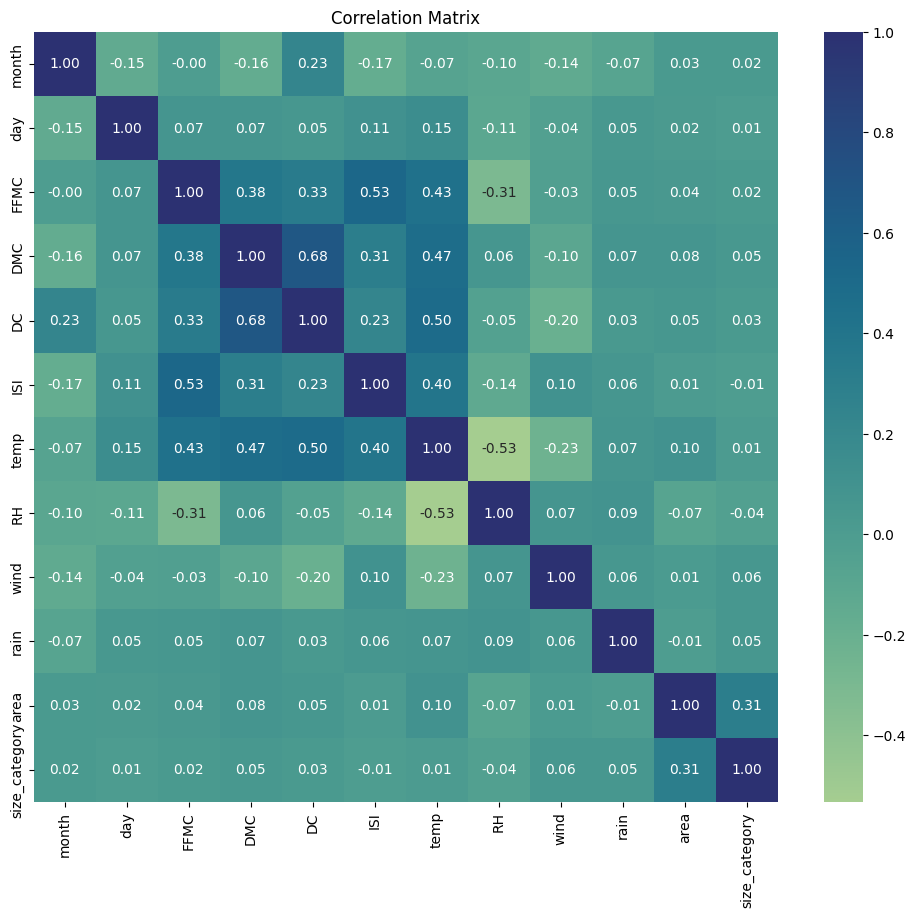

```python
# Using Seaborn to create a heatmap
plt.figure(figsize=(12, 10))
sbn.heatmap(corr_matrix, annot=True, cmap='crest', fmt='.2f')
plt.title('Correlation Matrix')
plt.show()
```

## Analysis:-

Feature Correlation with size_category

month: 0.024288 (very low)

day: 0.005360 (very low)

FFMC: 0.024292 (very low)

DMC: 0.046598 (very low)

DC: 0.028372 (very low)

ISI: -0.007867 (very low)

temp: 0.009976 (very low)

RH: -0.039730 (very low)

wind: 0.059513 (low)

rain: 0.053463 (low)

area: 0.310561 (moderate)

### Keep Features with Moderate/Low Correlation:

area: Shows a moderate correlation with the size_category. This feature might be more useful for the model.

wind:- Shows a low correlation with the size_category. This feature might be more useful for the model.

rain:- Shows a low correlation with the size_category. This feature might be more useful for the model.

```python
# Droping irrelevant features based on correlation matrix analysis due to very low coreelation with target value
dataSetRead = dataSetRead.drop(columns=['month','day','FFMC','DMC','DC', 'ISI','temp','RH'],axis=1)
```

## Data scaling

```python
# importing required package
# MinMax Scaler is used to perform feature scalling
from sklearn.preprocessing import MinMaxScaler
scalling=MinMaxScaler()
```

```python
# displaying list numerical columns toi scale
numerical_columns = ['wind', 'rain', 'area']

# performing Min-Max Scaling to the numerical columns
dataSetRead[numerical_columns] = scalling.fit_transform(dataSetRead[numerical_columns])
```

```python
# displaying all records in data set after Minmac scalling
dataSetRead
```

|  | wind | rain | area | size_category |
| --- | --- | --- | --- | --- |
| 0 | 0.700000 | 0.00000 | 0.000000 | 0 |
| 1 | 0.055556 | 0.00000 | 0.000000 | 0 |
| 2 | 0.100000 | 0.00000 | 0.000000 | 0 |
| 3 | 0.400000 | 0.03125 | 0.000000 | 0 |
| 4 | 0.155556 | 0.00000 | 0.000000 | 0 |
| ... | ... | ... | ... | ... |
| 512 | 0.255556 | 0.00000 | 0.005904 | 1 |
| 513 | 0.600000 | 0.00000 | 0.049769 | 1 |
| 514 | 0.700000 | 0.00000 | 0.010231 | 1 |
| 515 | 0.400000 | 0.00000 | 0.000000 | 0 |
| 516 | 0.455556 | 0.00000 | 0.000000 | 0 |

509 rows × 4 columns

# Q3) Write the code to split the dataset into training and testing sets with a 75-25 split. Hint: Consider target as size_category (1 M)

## Split data in to features & target

```python
# Dropping target variable
X=dataSetRead.drop('size_category',axis=1)
# Taking target variavle
y=dataSetRead['size_category']
```

```python
# Checking percentagewise distiribution for "size_category" target variable
dataSetRead['size_category'].value_counts(normalize=True).mul(100).round(2)
```

```
size_category
0    72.89
1    27.11
Name: proportion, dtype: float64
```

## Spliting the Data into Training and Testing Sets¶

```python
# Importing train_test_split package
from sklearn.model_selection import train_test_split
# Splitting train & test data
X_train,X_test,y_train,y_test=train_test_split(X,y,test_size=0.25,random_state=42,stratify=y)
```

```python
# Displaying dimenstion of train & test dataset
print('Shape of X_train = ', X_train.shape)
print('Shape of y_train = ', y_train.shape)
print('Shape of X_test = ', X_test.shape)
print('Shape of y_test = ', y_test.shape)
```

```
Shape of X_train =  (381, 3)
Shape of y_train =  (381,)
Shape of X_test =  (128, 3)
Shape of y_test =  (128,)
```

# Q4) Write the code to train SVM model with kernels (Linear, polynomial and RBF) and compare the performance. Also, calculate the accuracy scores for each kernel? (4 M)

```python
# Importing library of SVC
from sklearn.svm import SVC
from sklearn.metrics import accuracy_score, classification_report,confusion_matrix
```

```python
# Creating instance of SVM classifier with Linear Kernal
svm_Linear = SVC(kernel='linear')
```

```python
# Training the SVM model using training data set
svm_Linear.fit(X_train, y_train)
```

```
SVC(kernel='linear')
```

```python
# Prediction on test data for SVM classifier with Linear Kernal
y_prediction_svm_Linear=svm_Linear.predict(X_test)
```

```python
# Calculationg the accuracy of SVM classifier with Linear Kernal
accuracy_svm_Linear = accuracy_score(y_test, y_prediction_svm_Linear)
print("SVM model accuracy with Linear Kernal: {}".format(round(accuracy_svm_Linear,2)))
```

```
SVM model accuracy with Linear Kernal: 0.73
```

```python
# Evaluating classfication report for SVC classifier with Linear Kernal
report_svm_Linear=classification_report(y_test,y_prediction_svm_Linear)
print(report_svm_Linear)
```

```
              precision    recall  f1-score   support

           0       0.73      1.00      0.84        93
           1       0.00      0.00      0.00        35

    accuracy                           0.73       128
   macro avg       0.36      0.50      0.42       128
weighted avg       0.53      0.73      0.61       128
```

```python
# Evaluating confusion matrix for SVM classifier with Linear Kernal
conf_matrix_svm_Linear=confusion_matrix(y_test,y_prediction_svm_Linear)
print(conf_matrix_svm_Linear)
```

```
[[93  0]
 [35  0]]
```

```python
falsePositive_svm_Linear = conf_matrix_svm_Linear.sum(axis=0) - np.diag(conf_matrix_svm_Linear)
falseNegative_svm_Linear = conf_matrix_svm_Linear.sum(axis=1) - np.diag(conf_matrix_svm_Linear)
truePositive_svm_Linear = np.diag(conf_matrix_svm_Linear)
trueNegative_svm_Linear = conf_matrix_svm_Linear.sum() - (falsePositive_svm_Linear + falseNegative_svm_Linear + truePositive_svm_Linear)
print('************* SVM model with Linear Kernal*************')
for i in range(len(truePositive_svm_Linear)):
    print(f"Class {i}:")
    print(f"truePositive: {truePositive_svm_Linear[i]}, falsePositive: {falsePositive_svm_Linear[i]}, falseNegative: {falseNegative_svm_Linear[i]}, trueNegative: {trueNegative_svm_Linear[i]}")
    print()
```

```
************* SVM model with Linear Kernal*************
Class 0:
truePositive: 93, falsePositive: 35, falseNegative: 0, trueNegative: 0

Class 1:
truePositive: 0, falsePositive: 0, falseNegative: 35, trueNegative: 93
```

```python
# Creating instance of SVM classifier with Polynomial Kernal
svm_Polynomial = SVC(kernel='poly', degree=3)  # Polynomial kernel with degree 3
```

```python
# Training the SVM model using training data set
svm_Polynomial.fit(X_train, y_train)
```

```
SVC(kernel='poly')
```

```python
# Prediction on test data for SVM classifier with Polynomial Kernal
y_prediction_svm_Polynomial=svm_Polynomial.predict(X_test)
```

```python
# Calculationg the accuracy of SVM classifier with Polynomial Kernal
accuracy_svm_Polynomial = accuracy_score(y_test, y_prediction_svm_Polynomial)
print("SVM model accuracy with Polynomial Kernal: {}".format(round(accuracy_svm_Polynomial,2)))
```

```
SVM model accuracy with Polynomial Kernal: 0.86
```

```python
# Evaluating classfication report for SVM classifier with Polynomial Kernal
report_svm_Polynomial=classification_report(y_test,y_prediction_svm_Polynomial)
print(report_svm_Polynomial)
```

```
              precision    recall  f1-score   support

           0       0.84      1.00      0.91        93
           1       1.00      0.49      0.65        35

    accuracy                           0.86       128
   macro avg       0.92      0.74      0.78       128
weighted avg       0.88      0.86      0.84       128
```

```python
# Evaluating confusion matrix for SVM classifier with Polynomial Kernal
conf_matrix_svm_Polynomial=confusion_matrix(y_test,y_prediction_svm_Polynomial)
print(conf_matrix_svm_Polynomial)
```

```
[[93  0]
 [18 17]]
```

```python
falsePositive_svm_Polynomial = conf_matrix_svm_Polynomial.sum(axis=0) - np.diag(conf_matrix_svm_Polynomial)
falseNegative_svm_Polynomial = conf_matrix_svm_Polynomial.sum(axis=1) - np.diag(conf_matrix_svm_Polynomial)
truePositive_svm_Polynomial = np.diag(conf_matrix_svm_Polynomial)
trueNegative_svm_Polynomial = conf_matrix_svm_Polynomial.sum() - (falsePositive_svm_Polynomial + falseNegative_svm_Polynomial + truePositive_svm_Polynomial)
print('************* SVM model with Polynomial Kernal*************')
for i in range(len(truePositive_svm_Polynomial)):
    print(f"Class {i}:")
    print(f"truePositive: {truePositive_svm_Polynomial[i]}, falsePositive: {falsePositive_svm_Polynomial[i]}, falseNegative: {falseNegative_svm_Polynomial[i]}, trueNegative: {trueNegative_svm_Polynomial[i]}")
    print()
```

```
************* SVM model with Polynomial Kernal*************
Class 0:
truePositive: 93, falsePositive: 18, falseNegative: 0, trueNegative: 17

Class 1:
truePositive: 17, falsePositive: 0, falseNegative: 18, trueNegative: 93
```

```python
# Creating instance of SVM classifier with Radial Basis Function kernel
svm_RBF = SVC(kernel='rbf')
```

```python
# Training the SVM model using training data set
svm_RBF.fit(X_train, y_train)
```

```
SVC()
```

```python
# Prediction on test data for SVM classifier with Radial Basis Function kernel
y_prediction_svm_RBF=svm_RBF.predict(X_test)
```

```python
# Calculationg the accuracy of SVM classifier with Radial Basis Function kernel
accuracy_svm_RBF = accuracy_score(y_test, y_prediction_svm_RBF)
print("SVM model accuracy with Radial Basis Function kernel: {}".format(round(accuracy_svm_RBF,2)))
```

```
SVM model accuracy with Radial Basis Function kernel: 0.78
```

```python
# Evaluating classfication report for SVM classifier with Radial Basis Function kernel
report_svm_RBF=classification_report(y_test,y_prediction_svm_RBF)
print(report_svm_RBF)
```

```
              precision    recall  f1-score   support

           0       0.77      1.00      0.87        93
           1       1.00      0.20      0.33        35

    accuracy                           0.78       128
   macro avg       0.88      0.60      0.60       128
weighted avg       0.83      0.78      0.72       128
```

```python
# Evaluating confusion matrix for SVM classifier with Radial Basis Function kernel
conf_matrix_svm_RBF=confusion_matrix(y_test,y_prediction_svm_RBF)
print(conf_matrix_svm_RBF)
```

```
[[93  0]
 [28  7]]
```

```python
falsePositive_svm_RBS = conf_matrix_svm_RBF.sum(axis=0) - np.diag(conf_matrix_svm_RBF)
falseNegative_svm_RBS = conf_matrix_svm_RBF.sum(axis=1) - np.diag(conf_matrix_svm_RBF)
truePositive_svm_RBS = np.diag(conf_matrix_svm_RBF)
trueNegative_svm_RBS = conf_matrix_svm_RBF.sum() - (falsePositive_svm_RBS + falseNegative_svm_RBS + truePositive_svm_RBS)
print('************* SVM model with Radial Basis Function kernel*************')
for i in range(len(truePositive_svm_RBS)):
    print(f"Class {i}:")
    print(f"truePositive: {truePositive_svm_RBS[i]}, falsePositive: {falsePositive_svm_RBS[i]}, falseNegative: {falseNegative_svm_RBS[i]}, trueNegative: {trueNegative_svm_RBS[i]}")
    print()
```

```
************* SVM model with Radial Basis Function kernel*************
Class 0:
truePositive: 93, falsePositive: 28, falseNegative: 0, trueNegative: 7

Class 1:
truePositive: 7, falsePositive: 0, falseNegative: 28, trueNegative: 93
```

# Q5) Write a summary of which kernel performed best on test data and why. State conclusion properly. (1.5M)

### Summary and Conclusion

Performance Overview:

Linear Kernel: Achieved an accuracy of 73% on the test data. This kernel assumes a linear decision boundary and is suited for linearly separable data. However, the lower accuracy suggests that the linear assumption may not adequately capture the complexities in the data.

Polynomial Kernel: Achieved an accuracy of 86% on the test data. This kernel maps the data into a higher-dimensional space using polynomial functions, allowing the model to capture non-linear relationships and interactions in the data. The highest accuracy indicates that this kernel is particularly effective for the given dataset, suggesting that the data has complex patterns that a polynomial kernel can better model.

Radial Basis Function (RBF) Kernel: Achieved an accuracy of 78% on the test data. The RBF kernel also maps data into a higher-dimensional space but uses a Gaussian function to measure similarity between data points. While the RBF kernel improved performance over the linear kernel, it did not perform as well as the polynomial kernel.

Conclusion:

The polynomial kernel performed the best on the test data with an accuracy of 86%. This superior performance indicates that the polynomial kernel is particularly well-suited for the dataset, effectively capturing the non-linear patterns and interactions that the linear and RBF kernels could not fully model. The higher accuracy achieved with the polynomial kernel suggests that the decision boundaries required to separate the classes are complex and best represented by polynomial functions.

The RBF kernel, while improving upon the linear kernel, did not match the polynomial kernel’s performance, potentially due to suboptimal parameter settings or the nature of the data. Therefore, based on the test data performance, the polynomial kernel is the most effective choice for this specific problem.